# Homework 10

Kimberly McNeil

4/15/2026

# General Social Survey

## Recoding Marital Status

The following table showcases the distribution of respondents across the newly defined marital categories:[^1]

```r
gss_marital = gss_cat %>%
  mutate(
    marital_new = fct_collapse(
      marital,
      "Pre-Marriage" = "Never married",
      "Marriage" = c("Married", "Separated"),
      "Post-Marriage" = c("Divorced", "Widowed"),
      "Missing" = "No answer"
    )
  )

gss_marital %>%
  count(marital_new) %>%
  kable(caption = "Frequency Table for new Marital Levels")
```

Frequency Table for new Marital Levels

| marital_new | n |
| --- | --- |
| Missing | 17 |
| Pre-Marriage | 5416 |
| Marriage | 10860 |
| Post-Marriage | 5190 |

## Yearly Proportions of Marital Status

The following table showcases the first six rows of each year-marriage-status combination’s count and calculated proportion:[^2]

```r
marriage_year_summary = gss_marital %>%
  count(year, marital_new) %>%
  group_by(year) %>%
  mutate(prop = n / sum(n))

kable(head(marriage_year_summary), caption = "First Six Rows of Each Year-Marriage-Status Combination")
```

First Six Rows of Each Year-Marriage-Status Combination

| year | marital_new | n | prop |
| --- | --- | --- | --- |
| 2000 | Missing | 1 | 0.0003550 |
| 2000 | Pre-Marriage | 712 | 0.2527512 |
| 2000 | Marriage | 1390 | 0.4934327 |
| 2000 | Post-Marriage | 714 | 0.2534611 |
| 2002 | Pre-Marriage | 708 | 0.2560579 |
| 2002 | Marriage | 1365 | 0.4936709 |

```r
latest_year = max(marriage_year_summary$year) # select single col --> df$column_name

marriage_year_summary = marriage_year_summary %>%
  mutate(
    marital_new = fct_reorder(marital_new, year)
  )
```

## Line Plot of Proportion Versus Year

The following line plot showcases the marital status’ proportions over time in years, colored by our four marriage levels:[^4]

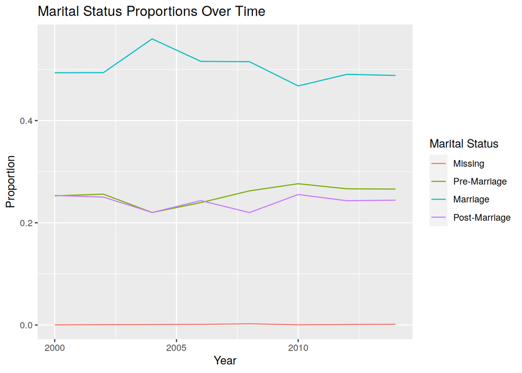

```r
ggplot(marriage_year_summary, aes(x = year, y = prop, color = marital_new)) +
  geom_line() +
  labs(
    title = "Marital Status Proportions Over Time",
    x = "Year",
    y = "Proportion",
    color = "Marital Status"
  )
```

# Los Angeles Lakers

## Directly Converting Integer Dates (Incorrect)

The following table showcases the first six rows of our new column that directly converts the date (integer data) column to a new column of date data:

```r
lakers_dates_bad = lakers %>%
  mutate(
    game_date = make_datetime(date),
    .keep = "used")

kable(head(lakers_dates_bad), caption = "First Six Rows of Incorrect Game Date Conversion")
```

First Six Rows of Incorrect Game Date Conversion

| date | game_date |
| --- | --- |
| 20081028 | 20081028-01-01 |
| 20081028 | 20081028-01-01 |
| 20081028 | 20081028-01-01 |
| 20081028 | 20081028-01-01 |
| 20081028 | 20081028-01-01 |
| 20081028 | 20081028-01-01 |

We can see how the direct conversion from a single integer turns every date January 1st, a very large year. We can guess this happens because it is taking the entire date as the first argument in the make_datetime() function, turning it into the year while every other argument (month, day, etc) becomes their default values.[^5]

## Date Conversion via Strings (Correct)

The following table showcases the first six rows of our new column that converts the date column to strings and then converts the string to date data:

```r
lakers_dates_good = lakers %>%
  mutate(game_date = ymd(as.character(date)))

kable(head(
  lakers_dates_good %>%
             select(date,
                    game_date,
                    opponent,
                    game_type)),
      caption = "First Six Rows of Correct Game Date Conversion")
```

First Six Rows of Correct Game Date Conversion

| date | game_date | opponent | game_type |
| --- | --- | --- | --- |
| 20081028 | 2008-10-28 | POR | home |
| 20081028 | 2008-10-28 | POR | home |
| 20081028 | 2008-10-28 | POR | home |
| 20081028 | 2008-10-28 | POR | home |
| 20081028 | 2008-10-28 | POR | home |
| 20081028 | 2008-10-28 | POR | home |

This method works better because we are conserving the YYYMMDD format, which allows ymd() to correctly parse the date.[^6]

## Games by the Day of the Week

The following bar plot showcases the frequency of games on every distinct day of the week:[^7]

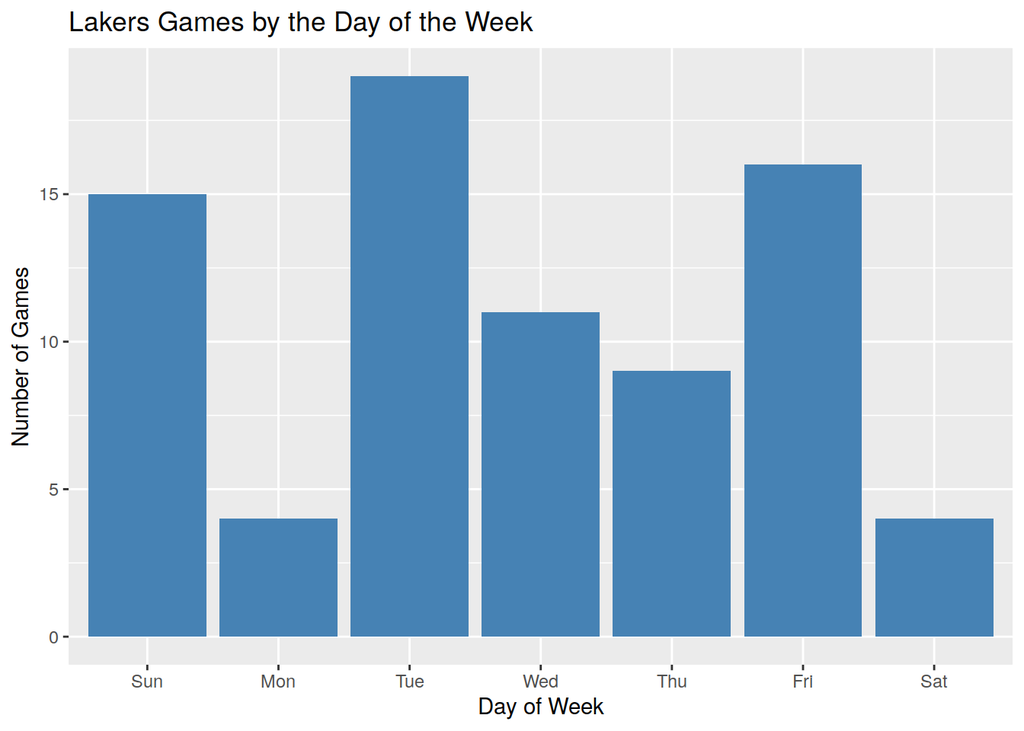

```r
lakers_wday = lakers_dates_good %>%
  distinct(game_date) %>%
  mutate(day = wday(game_date, label = TRUE, abbr = TRUE))

ggplot(lakers_wday, aes(x = day)) +
  geom_bar(fill = "steelblue") +
  labs(
    title = "Lakers Games by the Day of the Week",
    x = "Day of Week",
    y = "Number of Games"
  )
```

[^1]: Question 1 Complete
[^2]: Question 2 Complete
[^3]: Question 3 Complete
[^4]: Question 4 Complete
[^5]: Question 1 Complete
[^6]: Question 2 Complete
[^7]: Question 3 Complete